# Practical Machine Learning Course Project

## Overview

When using devices such as *Jawbone Up*, *Nike FuelBand*, and *Fitbit*, this is able to collect large amount of data about personal activity. However we noticed that majority of the people tends to focus on how much of a particular activity they do, rather than focus on how well they do it.

In this project, the data that will be used is taken from the accelerometers on the belt, forearm, arm and dumbell of 6 participants. They were asked to perform barbell lifts correctly and incorrectly in 5 different ways. The training data contains accelerometer data and a ‘classe’ label which representing the method of the activity the participants were doing. Whereas the testing data contains accelerometer data without the ‘classe’ label. The objective of the project is to predict the labels for the test set observations.

## Data

The training data for this project are available [here](https://d396qusza40orc.cloudfront.net/predmachlearn/pml-training.csv)

The test data are available [here](https://d396qusza40orc.cloudfront.net/predmachlearn/pml-testing.csv)

### Libraries

```r
library(lattice)
library(ggplot2)
library(caret)
library(randomForest)
library(rpart)
library(rpart.plot)
library(corrplot)
```

## Data Processing

### Loading data

```r
# reading training set data
trainingdata <- read.csv("pml-training.csv", na.strings = c("NA", ""))
# reading testing set data
testingdata <- read.csv("pml-testing.csv", na.strings = c("NA", ""))
dim(trainingdata)
```

```
## [1] 19622   160
```

```r
dim(testingdata)
```

```
## [1]  20 160
```

Above dimensions showed that the training data and testing data have 19622 observations and 20 observations respectively. Both of the data sets contain 160 variables. ‘classe’ variable in training data is the outcome that we are going to predict.

### Cleaning data

```r
#Remove observations that contains missing values
trainingdata <- trainingdata[, colSums(is.na(trainingdata)) == 0]
testingdata <- testingdata[, colSums(is.na(testingdata)) == 0]
```

The first 7 variables/predictors will be removed because these variables less influential prediction on the ‘classe’ outcome.

```r
#Subset the columns and data that required for analysis
trainCleanData <- trainingdata[, -c(1:7)]
testCleanData <- testingdata[, -c(1:7)]
dim(trainCleanData)
```

```
## [1] 19622    53
```

```r
dim(testCleanData)
```

```
## [1] 20 53
```

After data cleaning, the training data and testing data now contain 53 variables only (their observations rows still remained the same). The difference of these two data sets is the last column, that training data ended with ‘classe’ variable, while testing data ended with ‘problem_id’ variable.

## Data Modeling

### Split training data to 7:3 ratio for cross validation

We then split the cleaned training data into a training data set (70%) and a validation data set (30%). The validation data set is meant to use for cross validation, that we will be calculating the out-of-sample errors.

```r
set.seed(3579) # for reproducible
inTrain <- createDataPartition(trainCleanData$classe, p=0.70, list=FALSE)
trainDataSet <- trainCleanData[inTrain, ]
testDataSet <- trainCleanData[-inTrain, ]
```

### Use Random Forests Prediction Model

The **Random Forests** algorithm is one of the best among classification algorithms due to able to classify large amounts of data with accuracy. With that, **Random Forests** algorithm is chosen in the prediction model together with *5-fold cross-validation* on the ‘trainDataSet’.

```r
controlRF <- trainControl(method="cv", 5) # 5 fold cross validation
modelRF <- train(classe ~ ., data=trainDataSet, method="rf", trControl=controlRF, ntree=250)
modelRF
```

```
## Random Forest
##
## 13737 samples
##    52 predictor
##     5 classes: 'A', 'B', 'C', 'D', 'E'
##
## No pre-processing
## Resampling: Cross-Validated (5 fold)
## Summary of sample sizes: 10991, 10990, 10989, 10989, 10989
## Resampling results across tuning parameters:
##
##   mtry  Accuracy   Kappa
##    2    0.9911189  0.9887645
##   27    0.9914831  0.9892267
##   52    0.9831842  0.9787281
##
## Accuracy was used to select the optimal model using  the largest value.
## The final value used for the model was mtry = 27.
```

### Cross check accuracy and validation

Now, we examine the performance of the model on the validation data set.

```r
predictRF <- predict(modelRF, testDataSet)
confMatRF <- confusionMatrix(testDataSet$classe, predictRF)

accuracyRF <- confMatRF$overall[1]
accuracyRF
```

```
##  Accuracy
## 0.9935429
```

```r
OutSampleErr <- 1 - as.numeric(accuracyRF)
OutSampleErr
```

```
## [1] 0.006457094
```

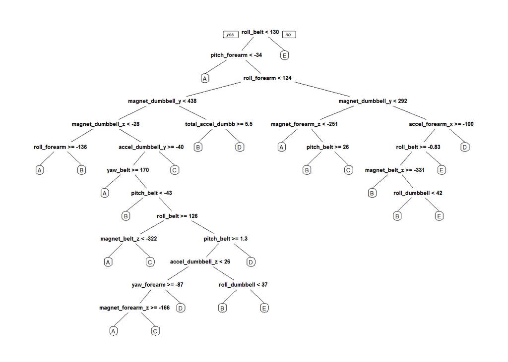

```r
#Decision Visualization
treeModel <- rpart(classe ~ ., data=trainDataSet, method="class")
prp(treeModel)
```

### Perform prediction for the Test Data

To achieve the goal of the project, **Random Forests** model will be applied to the cleaned testing data to predict the outcome variable ‘classe’.

```r
#Define write files function
pml_write_files = function(x) {
  n = length(x)
  for (i in 1:n) {
    filename = paste0("./prediction/problem_id_", i, ".txt")
    write.table(x[i], file=filename, quote=FALSE,row.names=FALSE, col.names=FALSE)
  }
}

result <- predict(modelRF, testingdata[, -length(names(testingdata))])
result
```

```
##  [1] B A B A A E D B A A B C B A E E A B B B
## Levels: A B C D E
```

```r
#Write the prediction result to files
pml_write_files(result)
```

## Conclusion

**Random Forests** model that was chosen in this course project able to show high accuracy in prediction, hence this model was applied to the 20 test cases to predict the ‘classe’ variable.